# IJBW Cooporative Society

Annual Financial Report | 2024

Author

Oluwadunni

Published

January 3, 2025

# Executive Summary

The 2024 fiscal year saw notable growth across most key financial metrics compared to the previous year. Annual member contributions reached **₦4.85 million**, reflecting an 11.4% year-over-year increase. Loan disbursements surged by 23.1% totaling **₦27.81 million**, while loan repayments declined by 14.4% to **₦22.93 million**. Income earned from loan interest grew proportionally with disbursements, increasing by 23.1% to **₦1.67 million** based on a fixed 6% interest rate structure. Notably, savings withdrawals decreased significantly by 32.7% to **₦1.15 million** reinforcing members’ behavior toward long-term savings accumulation.

This report presents a comprehensive analysis of these financial metrics, identifying trends, patterns, and opportunities for strategic improvement in the upcoming fiscal year.

*Financial Performance Summary*

| Metric | 2023 | 2024 | Change (%) |
| --- | --- | --- | --- |
| Member Contributions | ₦4.35M | ₦4.85M | +11.4% |
| Loan Disbursements | ₦22.59M | ₦27.81M | +23.1% |
| Loan Repayments | ₦26.79M | ₦22.93M | -14.4% |
| Income | ₦1.36M | ₦1.67M | +23.1% |
| Withdrawals | ₦1.71M | ₦1.15M | -32.7% |

# Contributions Analysis

The line chart below compares monthly contributions for 2023 and 2024, highlighting trends and differences in saving behavior across both years.

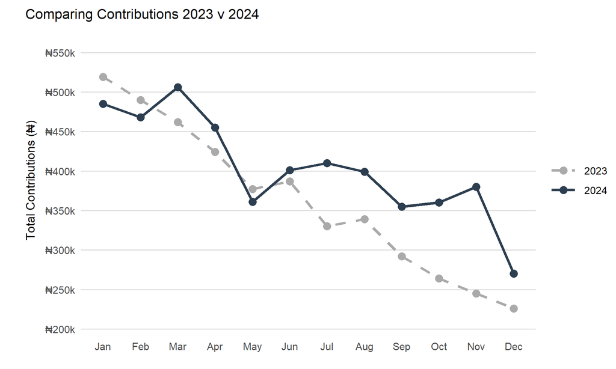

While 2023 had a higher peak in January, savings in 2024 quickly caught up and even surpassed 2023 by March. However, in both years, contributions started to decline from April onwards, with 2024 maintaining a slightly stronger trend for most of the year. There was a small rebound in November, but savings dropped sharply in December. This dip towards the end of the year could be because most members had already met their annual savings goals. The overall 11.4% increase in contributions reflects growing member engagement and confidence in the cooperative’s financial management.

# Loan Portfolio Analysis

Access to credit is a core objective of this cooperative society, aimed at supporting members’ financial needs. This section examines loan disbursement patterns over the year as well as distribution of loan amounts.

## Disbursement Trends

By comparing loan amounts disbursed across months, we can better understand when members seek financial support the most and how lending activities fluctuate throughout the year.

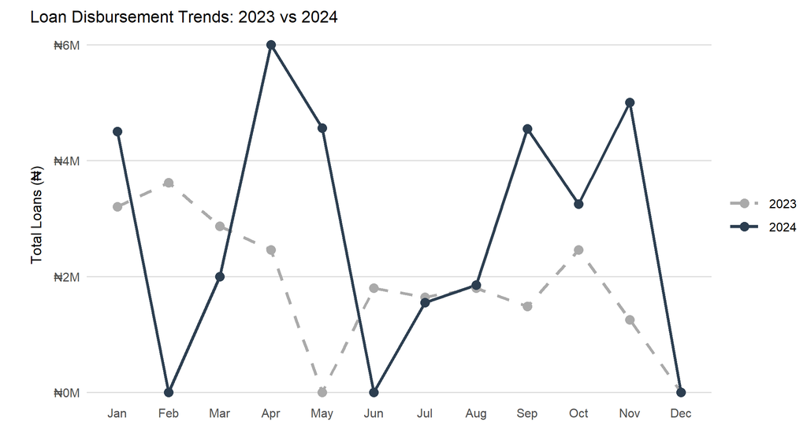

## Loan Size distribution

Understanding the distribution of loan amounts provides insights into borrowing behavior within the cooperative.

This insight can help in refining loan policies and assessing members’ credit needs.

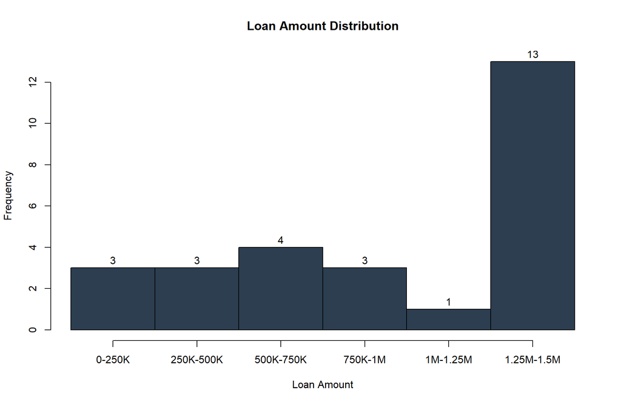

The loan amount distribution indicates a strong preference among members for the maximum loan amount available, as the highest category (₦1.25M–₦1.5M) has the highest frequency (13 loans). This suggests that most members tend to secure the largest possible loan, likely to meet substantial financial needs. Smaller loan amounts (₦0–₦1M) are significantly less common, with each range containing only 3–4 loans, while the ₦1M–₦1.25M category has just one loan.

## Loan Repayment

While the total loan repayment transactions for the year amounted to **₦22.9M**, only about **₦8M** was specifically for loans disbursed in 2024.This indicates a significant portion of repayments applied to prior-year loans.

The current year loan repayment status can be categorized as: fully repaid, partially repaid, not yet repaid(no payments at all) and overdue loans, to assess members’ commitment to loan repayment

*Loan Repayment Summary*

| Status | Number of Loans | Total Principal (₦) | Amount Repaid (₦) | Amount Outstanding (₦) | Repayment Rate (%) |
| --- | --- | --- | --- | --- | --- |
| Fully Repaid | 3 | ₦4,500,000.00 | ₦4,500,000.00 | ₦0.00 | 100.00% |
| Not Yet Repaid | 8 | ₦8,020,000.00 | ₦0.00 | ₦8,020,000.00 | 0.00% |
| Partially Repaid | 16 | ₦15,290,000.00 | ₦4,030,000.00 | ₦11,260,000.00 | 26.36% |
| Overdue | 0 | ₦0.00 | ₦0.00 | ₦0.00 | 0.00% |
| Total | 27 | ₦27,810,000.00 | ₦8,530,000.00 | ₦19,280,000.00 | 30.67% |

# Dividend Distribution

This section outlines how each member’s dividend is calculated based on their savings balance and loan utilization during the fiscal year. This transparent approach ensures all members understand how their financial participation affects their dividend returns. The total amount allocated for dividends this year was **₦1.66M**, derived primarily from interest earnings on loans disbursed to members. At the end of each fiscal year, dividends are distributed to members based on a weighted allocation model that ensures fairness. This model distributes 60% of the total income based on savings balances and 40% based on loan engagement.

## Dividend Distribution Formula

Each member’s dividend consists of two components:

- **Savings Dividend**:
  $$\text{Savings Dividend} = 60\% \times \text{Total Income} \times \frac{\text{Member's Savings Balance}}{\text{Total Savings of All Members}}$$
- **Loan Dividend**:
  $$\text{Loan Dividend} = 40\% \times \text{Total Income} \times \frac{\text{Member's loan obtained in 2024}}{\text{Total Loans Issued to All Members}}$$

The total dividend for each member is calculated as:
$$\text{Net Dividend} = \text{Savings Dividend} + \text{Loan Dividend}$$

This approach equitably rewards members for both their commitment to savings and their engagement with cooperative loan services—two critical pillars of the society’s financial sustainability.

*Note: dividend are subject to deductions before being disbursed to members for example for penalties and other expenses incurred in running the society as a whole*

# Insights and Recommendations

## Insights from 2024 Performance

The financial analysis reveals several noteworthy patterns that could influence strategic consideration.

- Growth trajectory in member contributions demonstrates growing trust and engagement with cooperative despite the seasonal decline pattern observed in both 2023 and 2024
- Significant increase in loan disbursements, coupled with the concetration of loans in the highest amount category (1.25M-1.5M) indicates strong demand for substantial financing among members
- The absence of overdue loans reflects excellent repayment discipline within the membership, though the overall repayment rate appears low due to timing factors rather than delinquency concerns.
- The substantial decrease in withdrawals coupled with increased contributions suggests members are increasingly viewing the cooperative as a long-term savings plan rather than a short-term liquidity solution.

## Recommendations

Based on these insights, the following initiatives have been proposed for 2025:

- Develop strategies and incentives to counter contribution decline such as special interest bonuses for maintaining monthly contribution streaks. Financial literacy sessions to help members understand the connection between their contribution patterns, loan utilizations and dividend earnings.
- Explore oppurtunities to slightly diversify income sources beyond loan interest, such as small investment ventures, or partnerships with local businesses to offer even more benefits to members.
- Consider implementing a tiered interest rate structure that offers slightly lower rates for smaller loans to encourage more diverse loan sizes and reduce concetration in maximum category.

## Personal Statements

To view your individual 2024 financial statement, including,contribution history, and loan details, please **[click here to access your personal statement](https://5a90nh-dunni-olu0ajayi.shinyapps.io/statement/)**.

*Note: You will need to input your member id to filter for your own statement.*